# Introduction to Computer Vision: Plant Seedlings Classification

## Problem Statement

### Context

In recent times, the field of agriculture has been in urgent need of modernizing, since the amount of manual work people need to put in to check if plants are growing correctly is still highly extensive. Despite several advances in agricultural technology, people working in the agricultural industry still need to have the ability to sort and recognize different plants and weeds, which takes a lot of time and effort in the long term. The potential is ripe for this trillion-dollar industry to be greatly impacted by technological innovations that cut down on the requirement for manual labor, and this is where Artificial Intelligence can actually benefit the workers in this field, as **the time and energy required to identify plant seedlings will be greatly shortened by the use of AI and Deep Learning.** The ability to do so far more efficiently and even more effectively than experienced manual labor, could lead to better crop yields, the freeing up of human inolvement for higher-order agricultural decision making, and in the long term will result in more sustainable environmental practices in agriculture as well.

### Objective

The aim of this project is to Build a Convolutional Neural Netowrk to classify plant seedlings into their respective categories.

### Data Dictionary

The Aarhus University Signal Processing group, in collaboration with the University of Southern Denmark, has recently released a dataset containing **images of unique plants belonging to 12 different species.**

- The dataset can be download from Olympus.
- The data file names are:
  - images.npy
  - Label.csv
- Due to the large volume of data, the images were converted to the images.npy file and the labels are also put into Labels.csv, so that you can work on the data/project seamlessly without having to worry about the high data volume.
- The goal of the project is to create a classifier capable of determining a plant's species from an image.

**List of Species**

- Black-grass
- Charlock
- Cleavers
- Common Chickweed
- Common Wheat
- Fat Hen
- Loose Silky-bent
- Maize
- Scentless Mayweed
- Shepherds Purse
- Small-flowered Cranesbill
- Sugar beet

#### **Note: Please use GPU runtime to execute the code efficiently**

## Importing necessary libraries

```python
import numpy as np                                                                               # Importing numpy for Matrix Operations
import pandas as pd                                                                              # Importing pandas to read CSV files
import matplotlib.pyplot as plt                                                                  # Importting matplotlib for Plotting and visualizing images
import cv2                                                                                       # Importing openCV for image processing
import seaborn as sns                                                                            # Importing seaborn to plot graphs


# Tensorflow modules
import tensorflow as tf
from tensorflow.keras.preprocessing.image import ImageDataGenerator                              # Importing the ImageDataGenerator for data augmentation
from tensorflow.keras.models import Sequential                                                   # Importing the sequential module to define a sequential model
from tensorflow.keras.layers import Dense,Dropout,Flatten,Conv2D,MaxPooling2D,BatchNormalization # Defining all the layers to build our CNN Model
from tensorflow.keras.optimizers import Adam                                                     # Importing the optimizers which can be used in our model
from sklearn.model_selection import train_test_split                                             # Importing train_test_split function to split the data into train and test
from sklearn.metrics import classification_report                                                # Importing confusion_matrix to plot the confusion matrix
from sklearn.preprocessing import LabelBinarizer
# Display images using OpenCV
from sklearn.model_selection import train_test_split
from tensorflow.keras import backend
from keras.callbacks import ReduceLROnPlateau
import random
# Ignore warnings
import warnings
warnings.filterwarnings('ignore')
```

## Loading the dataset

```python
images_url = './images.npy'
labels_url = './Labels.csv'
```

```python
images = np.load(images_url)
labels = pd.read_csv(labels_url)
```

## Data Overview

### Understand the shape of the dataset

```python
print(images.shape)
print(labels.shape)
```

```
(4750, 128, 128, 3)
(4750, 1)
```

- There are 4750 images in the dataset
- Each image is of size 128x128, and they have 3 channels (BGR)
- There are also the same number of labels for the images

```python
labels.value_counts()
```

```
Label
Loose Silky-bent             654
Common Chickweed             611
Scentless Mayweed            516
Small-flowered Cranesbill    496
Fat Hen                      475
Charlock                     390
Sugar beet                   385
Cleavers                     287
Black-grass                  263
Shepherds Purse              231
Common wheat                 221
Maize                        221
Name: count, dtype: int64
```

#### Observation:

- There are 12 unique classes in the dataset
- The dataset is fairly imbalanced - the most common class has 654 images, while the least common class has 221 images

## Exploratory Data Analysis

- EDA is an important part of any project involving data.
- It is important to investigate and understand the data better before building a model with it.
- A few questions have been mentioned below which will help you understand the data better.
- A thorough analysis of the data, in addition to the questions mentioned below, should be done.
1. How are these different category plant images different from each other?
2. Is the dataset provided an imbalance? (Check with using bar plots)

```python
# make a function:
# input: images, labels
# Algorithm:
# a. Find the unique labels
# b. Find a random image for each label
# c. Display the image and the label
def display_images(images, labels):
    unique_labels = labels['Label'].unique()
    rows = 3                                                                        # Defining number of rows=3 and columns = 4 for the subplots
    cols = 4
    current_row = 0                                                                 # These are for looping through the rows and columns
    current_col = 0
    fig = plt.figure(figsize=(10, 8))                                               # Defining the figure size
    for label in unique_labels:
        label_df = labels[labels['Label'] == label]
        random_index = random.choice(label_df.index)
        image = images[random_index]
        ax = fig.add_subplot(rows, cols, current_row * cols + current_col + 1)
        ax.imshow(image)
        ax.set_title(label)
        current_row = current_row + 1
        if current_row == rows:
            current_row = 0
            current_col = current_col + 1
    plt.show()
```

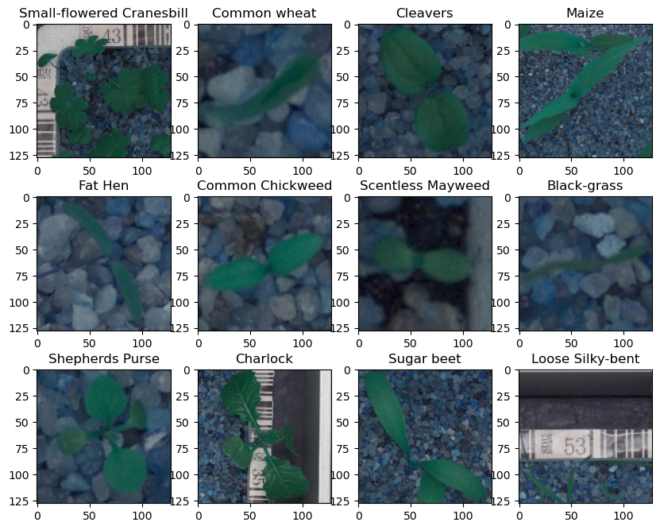

```python
display_images(images, labels)   # show each label with a random image
```

### Checking the distribution of the target variable

[output not shown]

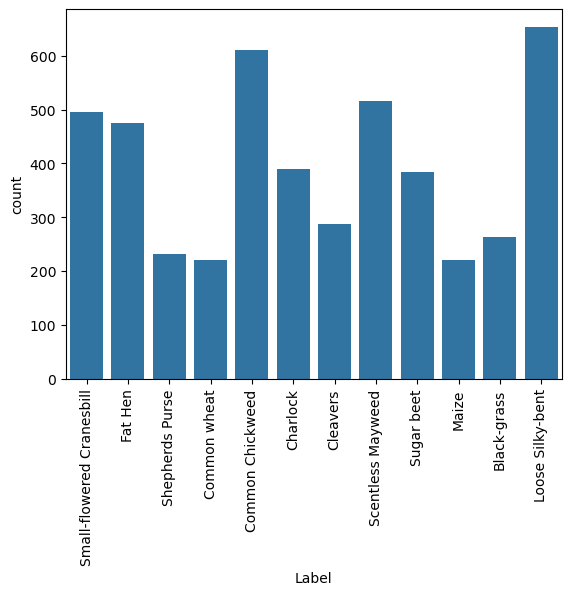

```python
sns.countplot(x=labels['Label'])
plt.xticks(rotation='vertical')
```

## Data Pre-Processing

### Convert the BGR images to RGB images.

```python
# Converting the images from BGR to RGB using cvtColor function of OpenCV
for i in range(len(images)):
  images[i] = cv2.cvtColor(images[i], cv2.COLOR_BGR2RGB)
```

### Resize the images

As the size of the images is large, it may be computationally expensive to train on these larger images; therefore, it is preferable to reduce the image size from 128 to 64.

```python
images_decreased=[]
dimensions = (64, 64)
for i in range(len(images)):
  images_decreased.append( cv2.resize(images[i], dimensions, interpolation=cv2.INTER_LINEAR))
```

**Image before resizing**

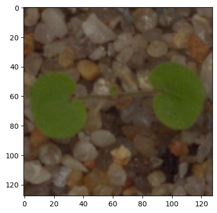

```python
plt.imshow(images[0])
```

**Image after resizing**

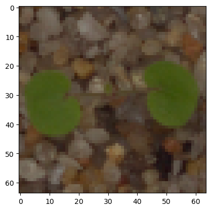

```python
plt.imshow(images_decreased[0])
```

#### Observations:

We can see that, by resizing to a smaller size, while the image is smaller, it also becomes a bit grainier. Whether this is beneficial or detrimental to the model's performance is unknown. While there are some details lost in the downsized image, the model may be able to classify the images better due to the loss of background noise (and in this particular case, the gravels introduced a lot of background noise, and the downsizing inadvertently removed a lot of that noise).

### Data Preparation for Modeling

- Before you proceed to build a model, you need to split the data into train, test, and validation to be able to evaluate the model that you build on the train data
- You'll have to encode categorical features and scale the pixel values.
- You will build a model using the train data and then check its performance

**Split the dataset**

```python
X_temp, X_test, y_temp, y_test = train_test_split(np.array(images_decreased),labels , test_size=0.1, random_state=1,stratify=labels)
X_train, X_val, y_train, y_val = train_test_split(X_temp,y_temp , test_size=0.1, random_state=1,stratify=y_temp)

print(X_train.shape)
print(X_val.shape)
print(X_test.shape)
print(y_train.shape)
print(y_val.shape)
print(y_test.shape)
```

```
(3847, 64, 64, 3)
(428, 64, 64, 3)
(475, 64, 64, 3)
(3847, 1)
(428, 1)
(475, 1)
```

### Encode the target labels

```python
# Convert labels from names to one hot vectors.

enc = LabelBinarizer()
y_train_encoded = enc.fit_transform(y_train)
y_val_encoded=enc.transform(y_val)
y_test_encoded=enc.transform(y_test)
```

```python
y_train_encoded.shape,y_val_encoded.shape,y_test_encoded.shape
```

```
((3847, 12), (428, 12), (475, 12))
```

### Data Normalization

```python
X_train_normalized = X_train.astype('float32')/255.0
X_val_normalized = X_val.astype('float32')/255.0
X_test_normalized = X_test.astype('float32')/255.0
```

## Model Building

```python
# Clearing backend
backend.clear_session()
```

```python
# Fixing the seed for random number generators
np.random.seed(1)
random.seed(1)
tf.random.set_seed(1)
```

```python
# Intializing a sequential model
model1 = Sequential()

model1.add(Conv2D(128, (3, 3), activation='relu', padding="same", input_shape=(64, 64, 3)))
model1.add(MaxPooling2D((2, 2), padding = 'same'))
model1.add(Conv2D(64, (3, 3), activation='relu', padding="same"))
model1.add(MaxPooling2D((2, 2), padding = 'same'))
model1.add(Conv2D(32, (3, 3), activation='relu', padding="same"))
model1.add(MaxPooling2D((2, 2), padding = 'same'))
model1.add(Flatten())
model1.add(Dense(16, activation='relu'))
model1.add(Dropout(0.3))
model1.add(Dense(12, activation='softmax'))

opt=Adam()
model1.compile(optimizer='adam', loss='categorical_crossentropy', metrics=['accuracy'])

model1.summary()
```

```
Model: "sequential"
_________________________________________________________________
 Layer (type)                Output Shape              Param #
=================================================================
 conv2d (Conv2D)             (None, 64, 64, 128)       3584

 max_pooling2d (MaxPooling2  (None, 32, 32, 128)       0
 D)

 conv2d_1 (Conv2D)           (None, 32, 32, 64)        73792

 max_pooling2d_1 (MaxPoolin  (None, 16, 16, 64)        0
 g2D)

 conv2d_2 (Conv2D)           (None, 16, 16, 32)        18464

 max_pooling2d_2 (MaxPoolin  (None, 8, 8, 32)          0
 g2D)

 flatten (Flatten)           (None, 2048)              0

 dense (Dense)               (None, 16)                32784

 dropout (Dropout)           (None, 16)                0

 dense_1 (Dense)             (None, 12)                204

=================================================================
Total params: 128828 (503.23 KB)
Trainable params: 128828 (503.23 KB)
Non-trainable params: 0 (0.00 Byte)
_________________________________________________________________
```

[output not shown]

**Fitting the model on the train data**

```python
history_1 = model1.fit(
            X_train_normalized, y_train_encoded,
            epochs=30,
            validation_data=(X_val_normalized,y_val_encoded),
            batch_size=32,
            verbose=2
)
```

[output not shown]

```
121/121 - 3s - loss: 2.4154 - accuracy: 0.1604 - val_loss: 2.2300 - val_accuracy: 0.2640 - 3s/epoch - 25ms/step
121/121 - 1s - loss: 2.1793 - accuracy: 0.2716 - val_loss: 1.9628 - val_accuracy: 0.3715 - 719ms/epoch - 6ms/step
121/121 - 1s - loss: 1.9825 - accuracy: 0.3132 - val_loss: 1.7191 - val_accuracy: 0.4743 - 723ms/epoch - 6ms/step
121/121 - 1s - loss: 1.7436 - accuracy: 0.3798 - val_loss: 1.5134 - val_accuracy: 0.5093 - 721ms/epoch - 6ms/step
121/121 - 1s - loss: 1.6300 - accuracy: 0.4086 - val_loss: 1.4009 - val_accuracy: 0.5304 - 757ms/epoch - 6ms/step
121/121 - 1s - loss: 1.5600 - accuracy: 0.4315 - val_loss: 1.4865 - val_accuracy: 0.5234 - 748ms/epoch - 6ms/step
121/121 - 1s - loss: 1.4876 - accuracy: 0.4523 - val_loss: 1.2091 - val_accuracy: 0.6495 - 728ms/epoch - 6ms/step
121/121 - 1s - loss: 1.3987 - accuracy: 0.4796 - val_loss: 1.2051 - val_accuracy: 0.6192 - 726ms/epoch - 6ms/step
121/121 - 1s - loss: 1.3885 - accuracy: 0.4903 - val_loss: 1.1661 - val_accuracy: 0.6355 - 732ms/epoch - 6ms/step
121/121 - 1s - loss: 1.3748 - accuracy: 0.4916 - val_loss: 1.2019 - val_accuracy: 0.6121 - 731ms/epoch - 6ms/step
121/121 - 1s - loss: 1.3237 - accuracy: 0.5077 - val_loss: 1.0676 - val_accuracy: 0.6752 - 733ms/epoch - 6ms/step
121/121 - 1s - loss: 1.2336 - accuracy: 0.5344 - val_loss: 1.0031 - val_accuracy: 0.6939 - 737ms/epoch - 6ms/step
121/121 - 1s - loss: 1.2229 - accuracy: 0.5516 - val_loss: 1.0238 - val_accuracy: 0.6846 - 740ms/epoch - 6ms/step
121/121 - 1s - loss: 1.1831 - accuracy: 0.5664 - val_loss: 1.0045 - val_accuracy: 0.6846 - 652ms/epoch - 5ms/step
121/121 - 1s - loss: 1.1676 - accuracy: 0.5688 - val_loss: 0.9901 - val_accuracy: 0.7150 - 644ms/epoch - 5ms/step
121/121 - 1s - loss: 1.1296 - accuracy: 0.5755 - val_loss: 1.0263 - val_accuracy: 0.6799 - 652ms/epoch - 5ms/step
121/121 - 1s - loss: 1.1299 - accuracy: 0.5818 - val_loss: 0.9606 - val_accuracy: 0.6986 - 686ms/epoch - 6ms/step
121/121 - 1s - loss: 1.0928 - accuracy: 0.5896 - val_loss: 1.0218 - val_accuracy: 0.6986 - 719ms/epoch - 6ms/step
121/121 - 1s - loss: 1.0623 - accuracy: 0.5994 - val_loss: 0.9667 - val_accuracy: 0.7220 - 663ms/epoch - 5ms/step
121/121 - 1s - loss: 1.0584 - accuracy: 0.6101 - val_loss: 0.9847 - val_accuracy: 0.7103 - 676ms/epoch - 6ms/step
121/121 - 1s - loss: 1.0333 - accuracy: 0.6090 - val_loss: 0.9438 - val_accuracy: 0.7173 - 681ms/epoch - 6ms/step
121/121 - 1s - loss: 1.0200 - accuracy: 0.6109 - val_loss: 0.9713 - val_accuracy: 0.7220 - 667ms/epoch - 6ms/step
121/121 - 1s - loss: 1.0095 - accuracy: 0.6171 - val_loss: 0.9478 - val_accuracy: 0.7173 - 673ms/epoch - 6ms/step
121/121 - 1s - loss: 0.9923 - accuracy: 0.6215 - val_loss: 0.9431 - val_accuracy: 0.7243 - 700ms/epoch - 6ms/step
121/121 - 1s - loss: 0.9831 - accuracy: 0.6267 - val_loss: 1.0237 - val_accuracy: 0.7243 - 674ms/epoch - 6ms/step
121/121 - 1s - loss: 0.9727 - accuracy: 0.6278 - val_loss: 0.9816 - val_accuracy: 0.7313 - 709ms/epoch - 6ms/step
121/121 - 1s - loss: 0.9569 - accuracy: 0.6314 - val_loss: 0.9488 - val_accuracy: 0.7360 - 710ms/epoch - 6ms/step
121/121 - 1s - loss: 0.9496 - accuracy: 0.6418 - val_loss: 0.9380 - val_accuracy: 0.7383 - 685ms/epoch - 6ms/step
121/121 - 1s - loss: 0.8996 - accuracy: 0.6603 - val_loss: 0.9557 - val_accuracy: 0.7290 - 686ms/epoch - 6ms/step
121/121 - 1s - loss: 0.9047 - accuracy: 0.6488 - val_loss: 0.9095 - val_accuracy: 0.7430 - 722ms/epoch - 6ms/step
```

**Model Evaluation**

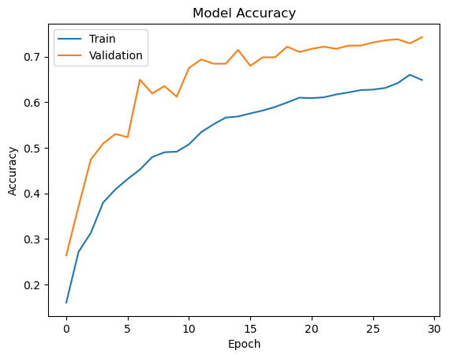

```python
plt.plot(history_1.history['accuracy'])
plt.plot(history_1.history['val_accuracy'])
plt.title('Model Accuracy')
plt.ylabel('Accuracy')
plt.xlabel('Epoch')
plt.legend(['Train', 'Validation'], loc='upper left')
plt.show()
```

#### Observations:

In this case, the validation accuracy is higher than the training accuracy. This is a bit unusual. Also, since the training accuracy is only around 60%, this means the model is not learning very well.

**Evaluate the model on test data**

```python
accuracy = model1.evaluate(X_test_normalized, y_test_encoded, verbose=2)
```

```
15/15 - 0s - loss: 0.9208 - accuracy: 0.7221 - 99ms/epoch - 7ms/step
```

**Plotting the Confusion Matrix**

```python
# Here we would get the output as probablities for each category
y_pred=model1.predict(X_test_normalized)
```

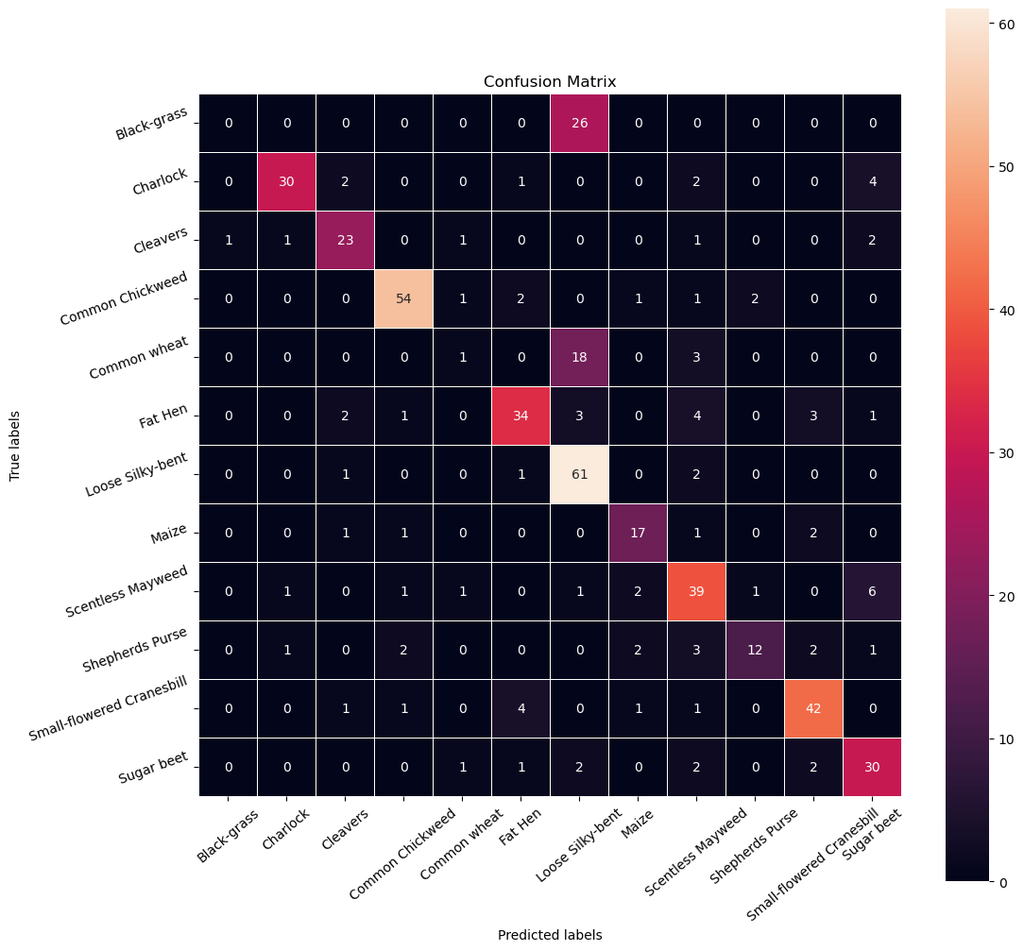

```python
# Obtaining the categorical values from y_test_encoded and y_pred
y_pred_arg=np.argmax(y_pred,axis=1)
y_test_arg=np.argmax(y_test_encoded,axis=1)

# Plotting the Confusion Matrix using confusion matrix() function which is also predefined in tensorflow module
confusion_matrix = tf.math.confusion_matrix(y_test_arg,y_pred_arg)
f, ax = plt.subplots(figsize=(12, 12))
sns.heatmap(
    confusion_matrix,
    annot=True,
    linewidths=.4,
    fmt="d",
    square=True,
    ax=ax
)
ax.set_xlabel('Predicted labels');ax.set_ylabel('True labels');
ax.set_title('Confusion Matrix');
ax.xaxis.set_ticklabels(list(enc.classes_),rotation=40)
ax.yaxis.set_ticklabels(list(enc.classes_),rotation=20)
plt.show()
```

**Plotting Classification Report**

```python
# Plotting the classification report
cr=classification_report(y_test_arg,y_pred_arg)
print(cr)
```

```
              precision    recall  f1-score   support

           0       0.00      0.00      0.00        26
           1       0.91      0.77      0.83        39
           2       0.77      0.79      0.78        29
           3       0.90      0.89      0.89        61
           4       0.20      0.05      0.07        22
           5       0.79      0.71      0.75        48
           6       0.55      0.94      0.69        65
           7       0.74      0.77      0.76        22
           8       0.66      0.75      0.70        52
           9       0.80      0.52      0.63        23
          10       0.82      0.84      0.83        50
          11       0.68      0.79      0.73        38

    accuracy                           0.72       475
   macro avg       0.65      0.65      0.64       475
weighted avg       0.69      0.72      0.69       475
```

#### Observations:

- Black-grass got the worst prediction: none of the actual black-grass images were predicted correctly, and they were almost all predicted as Loose Silky-bent. While this is not that surprising (since black-grass and loose silky-bent both have long, thin bodies), it still means that the CNN is not effectively learning about the differences - in fact, the learning all biased towards loose silky-bent.
- On the same note, the model seems also categorizing common wheat as loose silky-bent. This does not seem right, as common wheat's leave shape are rounder, therefore it should not cause the same confusion as black-grass did.
- Otherwise, the model did fairly well.

## Model Performance Improvement

**Reducing the Learning Rate:**

**Hint**: Use **ReduceLRonPlateau()** function that will be used to decrease the learning rate by some factor, if the loss is not decreasing for some time. This may start decreasing the loss at a smaller learning rate. There is a possibility that the loss may still not decrease. This may lead to executing the learning rate reduction again in an attempt to achieve a lower loss.

```python
# Code to monitor val_accuracy
learning_rate_reduction = ReduceLROnPlateau(monitor='val_accuracy',
                                            patience=3,
                                            verbose=1,
                                            factor=0.5,
                                            min_lr=0.00001)
```

### **Data Augmentation**

Remember, **data augmentation should not be used in the validation/test data set**.

```python
# Clearing backend
from tensorflow.keras import backend
backend.clear_session()

# Fixing the seed for random number generators
np.random.seed(1)
random.seed(1)
tf.random.set_seed(1)
```

```python
train_datagen = ImageDataGenerator(
                              rotation_range=20,
                              fill_mode='nearest'
                              )
```

```python
# Intializing a sequential model
model2 = Sequential()

model2.add(Conv2D(64, (3, 3), activation='relu', padding="same", input_shape=(64, 64, 3)))

model2.add(MaxPooling2D((2, 2), padding = 'same'))


model2.add(Conv2D(32, (3, 3), activation='relu', padding="same"))
model2.add(MaxPooling2D((2, 2), padding = 'same'))
model2.add(BatchNormalization())

model2.add(Flatten())

model2.add(Dense(16, activation='relu'))
model2.add(Dropout(0.3))

model2.add(Dense(12, activation='softmax'))

opt='adam'
model2.compile(optimizer=opt, loss='categorical_crossentropy', metrics=['accuracy'])

model2.summary()
```

```
Model: "sequential"
_________________________________________________________________
 Layer (type)                Output Shape              Param #
=================================================================
 conv2d (Conv2D)             (None, 64, 64, 64)        1792

 max_pooling2d (MaxPooling2  (None, 32, 32, 64)        0
 D)

 conv2d_1 (Conv2D)           (None, 32, 32, 32)        18464

 max_pooling2d_1 (MaxPoolin  (None, 16, 16, 32)        0
 g2D)

 batch_normalization (Batch  (None, 16, 16, 32)        128
 Normalization)

 flatten (Flatten)           (None, 8192)              0

 dense (Dense)               (None, 16)                131088

 dropout (Dropout)           (None, 16)                0

 dense_1 (Dense)             (None, 12)                204

=================================================================
Total params: 151676 (592.48 KB)
Trainable params: 151612 (592.23 KB)
Non-trainable params: 64 (256.00 Byte)
_________________________________________________________________
```

**Fitting the model on the train data**

```python
epochs = 30
batch_size = 64

history = model2.fit(train_datagen.flow(X_train_normalized,y_train_encoded,
                                       batch_size=batch_size,
                                       shuffle=False),
                                       epochs=epochs,
                                       steps_per_epoch=X_train_normalized.shape[0] // batch_size,
                                       validation_data=(X_val_normalized,y_val_encoded),
                                       verbose=1,callbacks=[learning_rate_reduction])
```

```
Epoch 9: ReduceLROnPlateau reducing learning rate to 0.0005000000237487257.
Epoch 16: ReduceLROnPlateau reducing learning rate to 0.0002500000118743628.
Epoch 23: ReduceLROnPlateau reducing learning rate to 0.0001250000059371814.
Epoch 26: ReduceLROnPlateau reducing learning rate to 6.25000029685907e-05.
Epoch 29: ReduceLROnPlateau reducing learning rate to 3.125000148429535e-05.
```

**Model Evaluation**

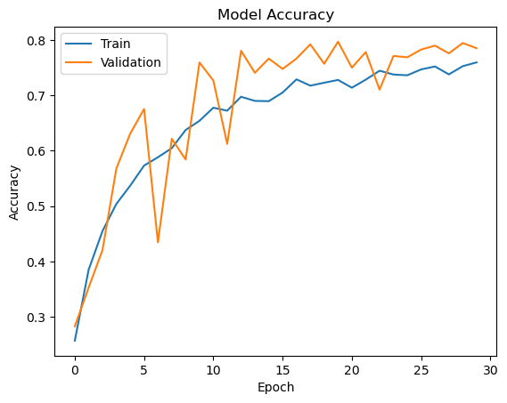

```python
plt.plot(history.history['accuracy'])
plt.plot(history.history['val_accuracy'])
plt.title('Model Accuracy')
plt.ylabel('Accuracy')
plt.xlabel('Epoch')
plt.legend(['Train', 'Validation'], loc='upper left')
plt.show()
```

#### Observations:

- The model's performance has substantially improved - both training and validation accuracy are now above 70%.
- Additionally, the training and validation accuracy are now much closer to each other, which shows that the model is learning well and not overfitting.

**Evaluate the model on test data**

```python
accuracy = model2.evaluate(X_test_normalized, y_test_encoded, verbose=2)
```

```
15/15 - 0s - loss: 0.6512 - accuracy: 0.7811 - 81ms/epoch - 5ms/step
```

**Plotting the Confusion Matrix**

```python
y_pred=model2.predict(X_test_normalized)
```

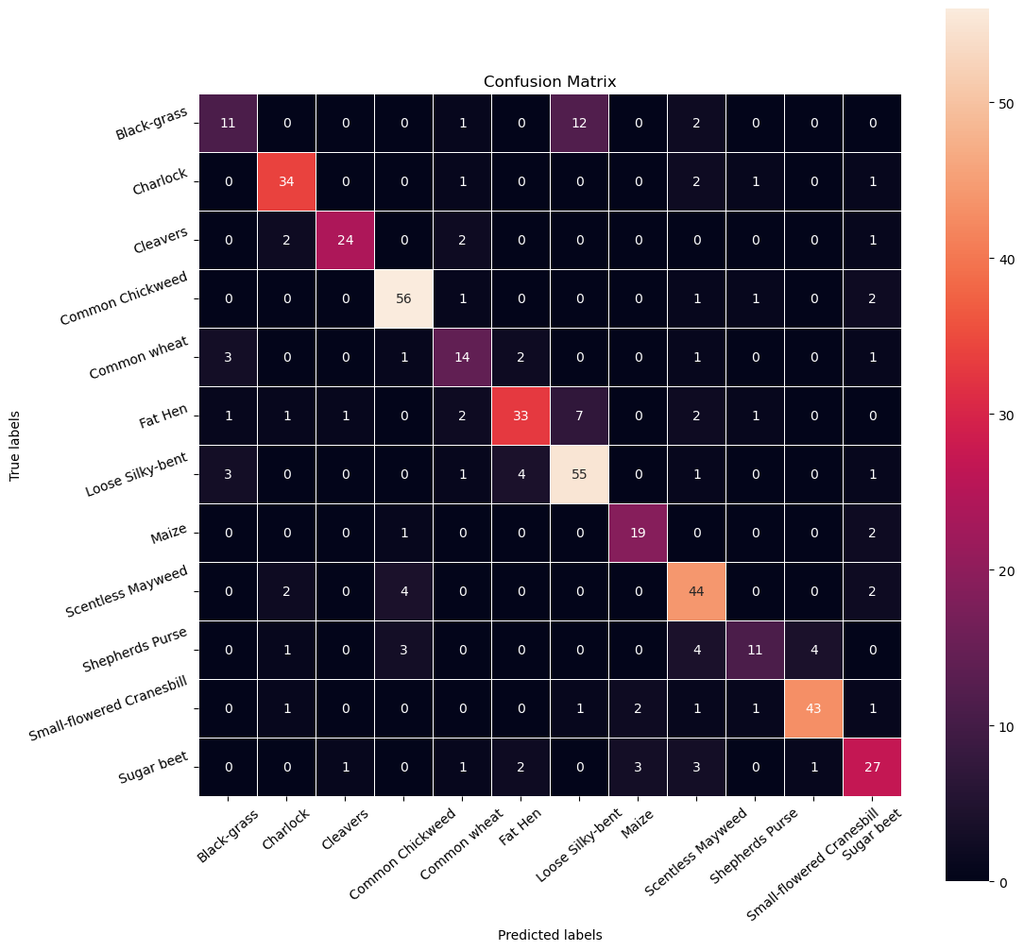

```python
# Obtaining the categorical values from y_test_encoded and y_pred
y_pred_arg=np.argmax(y_pred,axis=1)
y_test_arg=np.argmax(y_test_encoded,axis=1)

# Plotting the Confusion Matrix using confusion matrix() function which is also predefined in tensorflow module
confusion_matrix = tf.math.confusion_matrix(y_test_arg,y_pred_arg)
f, ax = plt.subplots(figsize=(12, 12))
sns.heatmap(
    confusion_matrix,
    annot=True,
    linewidths=.4,
    fmt="d",
    square=True,
    ax=ax
)
ax.set_xlabel('Predicted labels');ax.set_ylabel('True labels');
ax.set_title('Confusion Matrix');
ax.xaxis.set_ticklabels(list(enc.classes_),rotation=40)
ax.yaxis.set_ticklabels(list(enc.classes_),rotation=20)
plt.show()
```

**Plotting Classification Report**

```python
# Plotting the classification report
cr=classification_report(y_test_arg,y_pred_arg)
print(cr)
```

```
              precision    recall  f1-score   support

           0       0.61      0.42      0.50        26
           1       0.83      0.87      0.85        39
           2       0.92      0.83      0.87        29
           3       0.86      0.92      0.89        61
           4       0.61      0.64      0.62        22
           5       0.80      0.69      0.74        48
           6       0.73      0.85      0.79        65
           7       0.79      0.86      0.83        22
           8       0.72      0.85      0.78        52
           9       0.73      0.48      0.58        23
          10       0.90      0.86      0.88        50
          11       0.71      0.71      0.71        38

    accuracy                           0.78       475
   macro avg       0.77      0.75      0.75       475
weighted avg       0.78      0.78      0.78       475
```

#### Observations:

We also want to try out if the model performs better without reducing the image size in the first place.

## Model with original image size

```python
# Clearing backend
from tensorflow.keras import backend
backend.clear_session()

# Fixing the seed for random number generators
np.random.seed(1)
random.seed(1)
tf.random.set_seed(1)
```

```python
# name the new training set as XO instead of X, and YO instead of Y
XO_temp, XO_test, yo_temp, yo_test = train_test_split(np.array(images),labels , test_size=0.1, random_state=1,stratify=labels)
XO_train, XO_val, yo_train, yo_val = train_test_split(XO_temp,yo_temp , test_size=0.1, random_state=1,stratify=yo_temp)

print(XO_train.shape)
print(XO_val.shape)
print(XO_test.shape)
print(yo_train.shape)
print(yo_val.shape)
print(yo_test.shape)
```

```
(3847, 128, 128, 3)
(428, 128, 128, 3)
(475, 128, 128, 3)
(3847, 1)
(428, 1)
(475, 1)
```

```python
# Encode target labels

enc_org = LabelBinarizer()
yo_train_encoded = enc_org.fit_transform(yo_train)
yo_val_encoded=enc_org.transform(yo_val)
yo_test_encoded=enc_org.transform(yo_test)

yo_train_encoded.shape,yo_val_encoded.shape,yo_test_encoded.shape
```

```
((3847, 12), (428, 12), (475, 12))
```

```python
# Normalization
XO_train_normalized = XO_train.astype('float32')/255.0
XO_val_normalized = XO_val.astype('float32')/255.0
XO_test_normalized = XO_test.astype('float32')/255.0
```

```python
# Build model using the new, unreduced dataset
# Intializing a sequential model
model3 = Sequential()

model3.add(Conv2D(128, (3, 3), activation='relu', padding="same", input_shape=(128, 128, 3)))
model3.add(MaxPooling2D((2, 2), padding = 'same'))
model3.add(Conv2D(64, (3, 3), activation='relu', padding="same"))
model3.add(MaxPooling2D((2, 2), padding = 'same'))
model3.add(Conv2D(32, (3, 3), activation='relu', padding="same"))
model3.add(MaxPooling2D((2, 2), padding = 'same'))
model3.add(Flatten())
model3.add(Dense(16, activation='relu'))
model3.add(Dropout(0.3))
model3.add(Dense(12, activation='softmax'))

opt=Adam()
model3.compile(optimizer='adam', loss='categorical_crossentropy', metrics=['accuracy'])

model3.summary()
```

```
Model: "sequential"
_________________________________________________________________
 Layer (type)                Output Shape              Param #
=================================================================
 conv2d (Conv2D)             (None, 128, 128, 128)     3584

 max_pooling2d (MaxPooling2  (None, 64, 64, 128)       0
 D)

 conv2d_1 (Conv2D)           (None, 64, 64, 64)        73792

 max_pooling2d_1 (MaxPoolin  (None, 32, 32, 64)        0
 g2D)

 conv2d_2 (Conv2D)           (None, 32, 32, 32)        18464

 max_pooling2d_2 (MaxPoolin  (None, 16, 16, 32)        0
 g2D)

 flatten (Flatten)           (None, 8192)              0

 dense (Dense)               (None, 16)                131088

 dropout (Dropout)           (None, 16)                0

 dense_1 (Dense)             (None, 12)                204

=================================================================
Total params: 227132 (887.23 KB)
Trainable params: 227132 (887.23 KB)
Non-trainable params: 0 (0.00 Byte)
_________________________________________________________________
```

```python
# fit the model on the training data
history_3 = model3.fit(
            XO_train_normalized, yo_train_encoded,
            epochs=30,
            validation_data=(XO_val_normalized,yo_val_encoded),
            batch_size=32,
            verbose=2
)
```

```
121/121 - 4s - loss: 2.4385 - accuracy: 0.1424 - val_loss: 2.2546 - val_accuracy: 0.3154 - 4s/epoch - 35ms/step
121/121 - 2s - loss: 2.1926 - accuracy: 0.2615 - val_loss: 1.9802 - val_accuracy: 0.3341 - 2s/epoch - 19ms/step
121/121 - 2s - loss: 2.0273 - accuracy: 0.2870 - val_loss: 1.8083 - val_accuracy: 0.3808 - 2s/epoch - 19ms/step
121/121 - 2s - loss: 1.9010 - accuracy: 0.3109 - val_loss: 1.8375 - val_accuracy: 0.4743 - 2s/epoch - 19ms/step
121/121 - 2s - loss: 1.8724 - accuracy: 0.3174 - val_loss: 1.6853 - val_accuracy: 0.5023 - 2s/epoch - 19ms/step
121/121 - 2s - loss: 1.7611 - accuracy: 0.3444 - val_loss: 1.5018 - val_accuracy: 0.5117 - 2s/epoch - 19ms/step
121/121 - 2s - loss: 1.6963 - accuracy: 0.3691 - val_loss: 1.3828 - val_accuracy: 0.5467 - 2s/epoch - 20ms/step
121/121 - 2s - loss: 1.6393 - accuracy: 0.3941 - val_loss: 1.4036 - val_accuracy: 0.5304 - 2s/epoch - 19ms/step
121/121 - 2s - loss: 1.6012 - accuracy: 0.4027 - val_loss: 1.3443 - val_accuracy: 0.5257 - 2s/epoch - 19ms/step
121/121 - 2s - loss: 1.5682 - accuracy: 0.4149 - val_loss: 1.3496 - val_accuracy: 0.5771 - 2s/epoch - 19ms/step
121/121 - 2s - loss: 1.5428 - accuracy: 0.4177 - val_loss: 1.3966 - val_accuracy: 0.5304 - 2s/epoch - 19ms/step
121/121 - 2s - loss: 1.4371 - accuracy: 0.4578 - val_loss: 1.2748 - val_accuracy: 0.6051 - 2s/epoch - 19ms/step
121/121 - 2s - loss: 1.4282 - accuracy: 0.4736 - val_loss: 1.2528 - val_accuracy: 0.6449 - 2s/epoch - 19ms/step
121/121 - 2s - loss: 1.3791 - accuracy: 0.4819 - val_loss: 1.3057 - val_accuracy: 0.6121 - 2s/epoch - 19ms/step
121/121 - 2s - loss: 1.3886 - accuracy: 0.4892 - val_loss: 1.3006 - val_accuracy: 0.5935 - 2s/epoch - 19ms/step
121/121 - 2s - loss: 1.3732 - accuracy: 0.4754 - val_loss: 1.2714 - val_accuracy: 0.5958 - 2s/epoch - 19ms/step
121/121 - 2s - loss: 1.3534 - accuracy: 0.4840 - val_loss: 1.2255 - val_accuracy: 0.6308 - 2s/epoch - 18ms/step
121/121 - 2s - loss: 1.3056 - accuracy: 0.4991 - val_loss: 1.3505 - val_accuracy: 0.6308 - 2s/epoch - 19ms/step
121/121 - 2s - loss: 1.3252 - accuracy: 0.4957 - val_loss: 1.2495 - val_accuracy: 0.6402 - 2s/epoch - 19ms/step
121/121 - 2s - loss: 1.2889 - accuracy: 0.4988 - val_loss: 1.2727 - val_accuracy: 0.6308 - 2s/epoch - 19ms/step
121/121 - 2s - loss: 1.2720 - accuracy: 0.5045 - val_loss: 1.2576 - val_accuracy: 0.6379 - 2s/epoch - 19ms/step
121/121 - 2s - loss: 1.2490 - accuracy: 0.5251 - val_loss: 1.3913 - val_accuracy: 0.6145 - 2s/epoch - 19ms/step
121/121 - 2s - loss: 1.2586 - accuracy: 0.5326 - val_loss: 1.3160 - val_accuracy: 0.6238 - 2s/epoch - 19ms/step
121/121 - 2s - loss: 1.2441 - accuracy: 0.5352 - val_loss: 1.2393 - val_accuracy: 0.6659 - 2s/epoch - 18ms/step
121/121 - 2s - loss: 1.2494 - accuracy: 0.5321 - val_loss: 1.3462 - val_accuracy: 0.6542 - 2s/epoch - 19ms/step
121/121 - 2s - loss: 1.2255 - accuracy: 0.5350 - val_loss: 1.2706 - val_accuracy: 0.6542 - 2s/epoch - 18ms/step
121/121 - 2s - loss: 1.2024 - accuracy: 0.5422 - val_loss: 1.3294 - val_accuracy: 0.6402 - 2s/epoch - 19ms/step
121/121 - 2s - loss: 1.1980 - accuracy: 0.5407 - val_loss: 1.3858 - val_accuracy: 0.6355 - 2s/epoch - 19ms/step
121/121 - 2s - loss: 1.1872 - accuracy: 0.5532 - val_loss: 1.4254 - val_accuracy: 0.6425 - 2s/epoch - 19ms/step
121/121 - 2s - loss: 1.2066 - accuracy: 0.5407 - val_loss: 1.3513 - val_accuracy: 0.6612 - 2s/epoch - 19ms/step
```

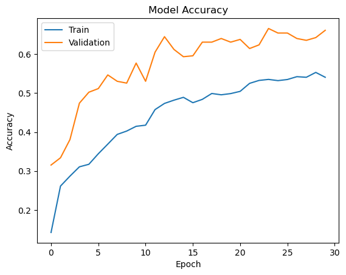

```python
# Model Evaluation

plt.plot(history_3.history['accuracy'])
plt.plot(history_3.history['val_accuracy'])
plt.title('Model Accuracy')
plt.ylabel('Accuracy')
plt.xlabel('Epoch')
plt.legend(['Train', 'Validation'], loc='upper left')
plt.show()
```

#### Observations:

The model performs actually much worse than the reduced image model. This means that the background noise that's removed by the downsizing actually outbenefits the loss of details in the image.

```python
# evaluate on test data
accuracy = model3.evaluate(XO_test_normalized, yo_test_encoded, verbose=2)
```

```
15/15 - 0s - loss: 1.2294 - accuracy: 0.6295 - 217ms/epoch - 14ms/step
```

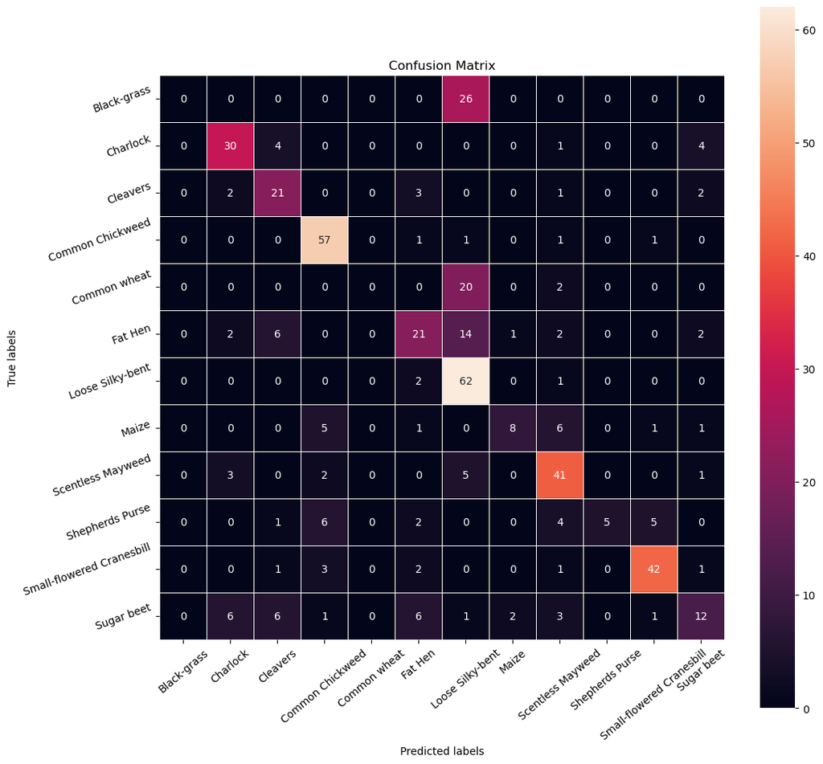

```python
# confusion matrix

yo_pred=model3.predict(XO_test_normalized)

# Obtaining the categorical values from y_test_encoded and y_pred
yo_pred_arg=np.argmax(yo_pred,axis=1)
yo_test_arg=np.argmax(yo_test_encoded,axis=1)

# Plotting the Confusion Matrix using confusion matrix() function which is also predefined in tensorflow module
confusion_matrix = tf.math.confusion_matrix(yo_test_arg,yo_pred_arg)
f, ax = plt.subplots(figsize=(12, 12))
sns.heatmap(
    confusion_matrix,
    annot=True,
    linewidths=.4,
    fmt="d",
    square=True,
    ax=ax
)
ax.set_xlabel('Predicted labels');ax.set_ylabel('True labels');
ax.set_title('Confusion Matrix');
ax.xaxis.set_ticklabels(list(enc.classes_),rotation=40)
ax.yaxis.set_ticklabels(list(enc.classes_),rotation=20)
plt.show()
```

#### Observations:

- The model performs worse than the reduced-image model - more types of plants are misclassified by a significant margin.

```python
# Plotting the classification report
cr=classification_report(yo_test_arg,yo_pred_arg)
print(cr)
```

```
              precision    recall  f1-score   support

           0       0.00      0.00      0.00        26
           1       0.70      0.77      0.73        39
           2       0.54      0.72      0.62        29
           3       0.77      0.93      0.84        61
           4       0.00      0.00      0.00        22
           5       0.55      0.44      0.49        48
           6       0.48      0.95      0.64        65
           7       0.73      0.36      0.48        22
           8       0.65      0.79      0.71        52
           9       1.00      0.22      0.36        23
          10       0.84      0.84      0.84        50
          11       0.52      0.32      0.39        38

    accuracy                           0.63       475
   macro avg       0.56      0.53      0.51       475
weighted avg       0.59      0.63      0.58       475
```

## Data augmentation with original image size

```python
# Code to monitor val_accuracy
learning_rate_reduction = ReduceLROnPlateau(monitor='val_accuracy',
                                            patience=3,
                                            verbose=1,
                                            factor=0.5,
                                            min_lr=0.00001)
```

```python
# Clearing backend
from tensorflow.keras import backend
backend.clear_session()

# Fixing the seed for random number generators
np.random.seed(1)
random.seed(1)
tf.random.set_seed(1)
```

```python
train_datagen = ImageDataGenerator(
                              rotation_range=20,
                              fill_mode='nearest'
                              )
```

```python
# Intializing a sequential model
model4 = Sequential()

model4.add(Conv2D(64, (3, 3), activation='relu', padding="same", input_shape=(128, 128, 3)))

model4.add(MaxPooling2D((2, 2), padding = 'same'))


model4.add(Conv2D(32, (3, 3), activation='relu', padding="same"))
model4.add(MaxPooling2D((2, 2), padding = 'same'))
model4.add(BatchNormalization())

model4.add(Flatten())

model4.add(Dense(16, activation='relu'))
model4.add(Dropout(0.3))

model4.add(Dense(12, activation='softmax'))

opt='adam'
model4.compile(optimizer=opt, loss='categorical_crossentropy', metrics=['accuracy'])

model4.summary()
```

```
Model: "sequential"
_________________________________________________________________
 Layer (type)                Output Shape              Param #
=================================================================
 conv2d (Conv2D)             (None, 128, 128, 64)      1792

 max_pooling2d (MaxPooling2  (None, 64, 64, 64)        0
 D)

 conv2d_1 (Conv2D)           (None, 64, 64, 32)        18464

 max_pooling2d_1 (MaxPoolin  (None, 32, 32, 32)        0
 g2D)

 batch_normalization (Batch  (None, 32, 32, 32)        128
 Normalization)

 flatten (Flatten)           (None, 32768)             0

 dense (Dense)               (None, 16)                524304

 dropout (Dropout)           (None, 16)                0

 dense_1 (Dense)             (None, 12)                204

=================================================================
Total params: 544892 (2.08 MB)
Trainable params: 544828 (2.08 MB)
Non-trainable params: 64 (256.00 Byte)
_________________________________________________________________
```

```python
epochs = 30
batch_size = 64

history_4 = model4.fit(train_datagen.flow(XO_train_normalized,yo_train_encoded,
                                       batch_size=batch_size,
                                       shuffle=False),
                                       epochs=epochs,
                                       steps_per_epoch=XO_train_normalized.shape[0] // batch_size,
                                       validation_data=(XO_val_normalized,yo_val_encoded),
                                       verbose=1,callbacks=[learning_rate_reduction])
```

```
Epoch 7: ReduceLROnPlateau reducing learning rate to 0.0005000000237487257.
Epoch 17: ReduceLROnPlateau reducing learning rate to 0.0002500000118743628.
Epoch 20: ReduceLROnPlateau reducing learning rate to 0.0001250000059371814.
Epoch 26: ReduceLROnPlateau reducing learning rate to 6.25000029685907e-05.
```

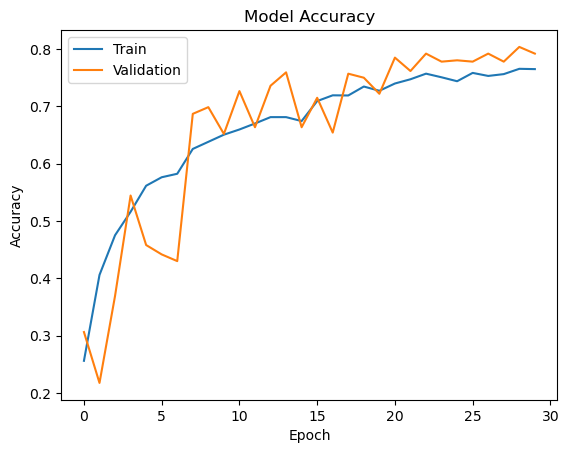

```python
# model evaluation
plt.plot(history_4.history['accuracy'])
plt.plot(history_4.history['val_accuracy'])
plt.title('Model Accuracy')
plt.ylabel('Accuracy')
plt.xlabel('Epoch')
plt.legend(['Train', 'Validation'], loc='upper left')
plt.show()
```

```python
accuracy = model4.evaluate(XO_test_normalized, yo_test_encoded, verbose=2)
```

```
15/15 - 0s - loss: 0.6709 - accuracy: 0.7789 - 152ms/epoch - 10ms/step
```

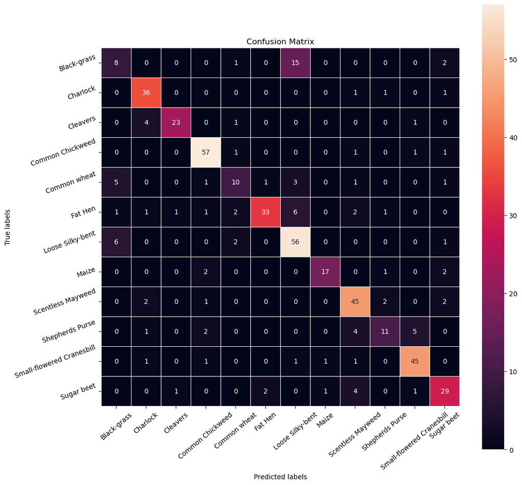

```python
yo_pred=model4.predict(XO_test_normalized)

# Obtaining the categorical values from y_test_encoded and y_pred
yo_pred_arg=np.argmax(yo_pred,axis=1)
yo_test_arg=np.argmax(yo_test_encoded,axis=1)

# Plotting the Confusion Matrix using confusion matrix() function which is also predefined in tensorflow module
confusion_matrix = tf.math.confusion_matrix(yo_test_arg,yo_pred_arg)
f, ax = plt.subplots(figsize=(12, 12))
sns.heatmap(
    confusion_matrix,
    annot=True,
    linewidths=.4,
    fmt="d",
    square=True,
    ax=ax
)
ax.set_xlabel('Predicted labels');ax.set_ylabel('True labels');
ax.set_title('Confusion Matrix');
ax.xaxis.set_ticklabels(list(enc.classes_),rotation=40)
ax.yaxis.set_ticklabels(list(enc.classes_),rotation=20)
plt.show()
```

#### Observations:

```python
# Plotting the classification report
cr=classification_report(yo_test_arg,yo_pred_arg)
print(cr)
```

```
              precision    recall  f1-score   support

           0       0.40      0.31      0.35        26
           1       0.80      0.92      0.86        39
           2       0.92      0.79      0.85        29
           3       0.88      0.93      0.90        61
           4       0.59      0.45      0.51        22
           5       0.92      0.69      0.79        48
           6       0.69      0.86      0.77        65
           7       0.89      0.77      0.83        22
           8       0.76      0.87      0.81        52
           9       0.69      0.48      0.56        23
          10       0.85      0.90      0.87        50
          11       0.74      0.76      0.75        38

    accuracy                           0.78       475
   macro avg       0.76      0.73      0.74       475
weighted avg       0.78      0.78      0.77       475
```

## Final Model

Comment on the final model you have selected and use the same in the below code to visualize the image.

```python
# based on the accuracy and confusion matrix, the model with data augmentation is better

final_model = model2
```

### Visualizing the prediction

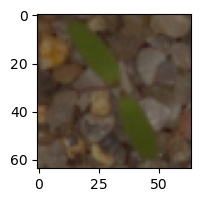

```
Predicted Label ['Fat Hen']
True Label Fat Hen
```

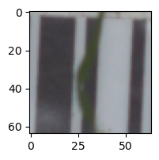

```
Predicted Label ['Loose Silky-bent']
True Label Black-grass
```

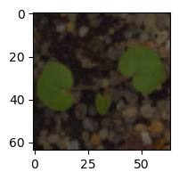

```
Predicted Label ['Small-flowered Cranesbill']
True Label Small-flowered Cranesbill
```

[figure not shown]

```
Predicted Label ['Charlock']
True Label Charlock
```

```python
# Visualizing the predicted and correct label of images from test data
plt.figure(figsize=(2,2))
plt.imshow(X_test[2])
plt.show()
## Complete the code to predict the test data using the final model selected
print('Predicted Label', enc.inverse_transform(final_model.predict((X_test_normalized[2].reshape(1,64,64,3)))))   # reshaping the input image as we are only trying to predict using a single image
print('True Label', enc.inverse_transform(y_test_encoded)[2])                                               # using inverse_transform() to get the output label from the output vector

plt.figure(figsize=(2,2))
plt.imshow(X_test[33])
plt.show()
## Complete the code to predict the test data using the final model selected
print('Predicted Label', enc.inverse_transform(final_model.predict((X_test_normalized[33].reshape(1,64,64,3)))))  # reshaping the input image as we are only trying to predict using a single image
print('True Label', enc.inverse_transform(y_test_encoded)[33])                                              # using inverse_transform() to get the output label from the output vector

plt.figure(figsize=(2,2))
plt.imshow(X_test[59],)
plt.show()
## Complete the code to predict the test data using the final model selected
print('Predicted Label', enc.inverse_transform(final_model.predict((X_test_normalized[59].reshape(1,64,64,3)))))  # reshaping the input image as we are only trying to predict using a single image
print('True Label', enc.inverse_transform(y_test_encoded)[59])                                              # using inverse_transform() to get the output label from the output vector

plt.figure(figsize=(2,2))
plt.imshow(X_test[36])
plt.show()
## Complete the code to predict the test data using the final model selected
print('Predicted Label', enc.inverse_transform(final_model.predict((X_test_normalized[36].reshape(1,64,64,3)))))  # reshaping the input image as we are only trying to predict using a single image
print('True Label', enc.inverse_transform(y_test_encoded)[36])                                              # using inverse_transform() to get the output label from the output vector
```

As we can see, the image of black-grass was wrongly classified as loose silky-bent. Other images were correctly classified.

## Actionable Insights and Business Recommendations

- The images obtained proved to be problematic, as the gravel ground introduced a lot of background noise, which reduced the model's learning ability. If budget allowed, it would be beneficial to obtain a new set of images with the plants up against a more uniform background.
- If the above is not possible, another possible way to improve the model is to make use of photo-editing software to remove the background noise while improve the sharpness of the plants themselves. This could be laberous, but it could theoretically improve the model's performance substantially.
- Certain plant types are very similar to each other, the most notable being black-grass and loose silky-bent. It may be beneficial to obtain more images of these plants to help the model distinguish between the two.
- Another way to improve the prediction between black-grass and loose silky-bent is to train using transfer learning.
- Ultimately, this model shows that the shape of the plants are more important, as reducing image size (thus losing details) actually improved the model's performance. This means, if there are plants that are very similar in shapes but different in details, the model would struggle to learn the differences. Therefore, it is even more important to obtain plants with a uniform background, so that no noise reduction (and detail loss) is necessary.